# Week 3: Batch effects and integration in Seurat v5

Kevin Z. Lin

2026-08-09

# 1 Overview

This tutorial was made from the Seurat v5 vignette *Integrative analysis in Seurat v5*, https://satijalab.org/seurat/articles/seurat5_integration, and the Azimuth mapping tutorial, https://satijalab.github.io/azimuth/articles/run_azimuth_tutorial.html.

Week 1 ran the whole pipeline on a single sample and pretended that was the normal case. It is not. Almost nobody has one sample. You have four donors, or two 10x runs done three weeks apart, or a pilot on one chemistry and the rest on another. And the moment you have more than one, a new failure mode appears: **the cells group by where they came from rather than by what they are.**

That is a batch effect, and it is not subtle. Run the Week 1 pipeline unchanged on a multi-sample dataset and you will often get one group per sample per cell type — a UMAP that looks like a technical inventory of your experiment rather than a picture of your biology.

The fix is called **integration**, and the single most important thing to understand about it is what it does *not* do:

> **Integration does not change your counts.** It produces a new low-dimensional embedding — a replacement for the PCA — in which cells of the same type from different batches sit on top of each other. Everything that consumes a reduction — UMAP, clustering, neighbour graphs — can then use it. But when you later test genes for differential expression, you go back to the original counts. Nothing in this tutorial edits a single count.

The plan:

| Stage | What it produces | Function |
| --- | --- | --- |
| 0. Label the cells against a reference | A cell type per cell, fixed before any integration happens | `RunAzimuth()` |
| 1. Declare the batches | One layer per batch inside the RNA assay | `split()` |
| 2. Run the Week 1 pipeline | Normalized data, variable genes, a PCA | `NormalizeData()` … `RunPCA()` |
| 3. Look at the damage | A UMAP in which cells group by technology | `RunUMAP()`, `DimPlot()` |
| 4. Integrate | A new reduction, `integrated.cca`, in which they do not | `IntegrateLayers()` |
| 5. Look again | The same cells, the same genes, batches mixed | `RunUMAP()`, `DimPlot()` |
| 6. Put the layers back together | One `counts` and one `data` layer, ready for testing | `JoinLayers()` |

Stage 0 is there for a specific reason. To judge whether integration worked, you need a read on each cell’s identity that does not itself depend on the integration. Anything computed *from* the integrated embedding — clusters above all — is circular evidence that it succeeded. Azimuth gives us an independent label per cell, assigned against an external reference, before any of the integration happens, and we never update it afterwards.

That is also why this tutorial never clusters. Integration produces a reduction; whether it worked is a question about that reduction, and two fixed labels — which batch a cell came from and which cell type it is — answer it without introducing a clustering algorithm and its resolution parameter as a confound.

> **Where this sits in the workshop.** The middle of this tutorial — normalize, pick variable genes, scale, PCA — is exactly the Week 3 material, run here on a dataset whose batch structure is impossible to ignore. The companion Week 3 tutorial takes the normalization step on its own and replaces this log-normalize / variable-genes / scale sequence with `SCTransform`. Batch correction runs across two sessions: this is part one, and **Week 4** returns to it — comparing integration methods and testing genes once the batches are aligned. Bulk deconvolution is **Week 5**.

# 2 Setting up

`Seurat` is on CRAN. `SeuratData` (which distributes the demonstration datasets) and `Azimuth` (which does the reference mapping) are not, so they install from GitHub with `devtools`. You only need to do this once, which is why the lines are commented out.

```r
# install.packages("devtools")
# devtools::install_github("satijalab/seurat-data")
# devtools::install_github("satijalab/azimuth")
```

```r
library(Seurat)
library(SeuratData)
library(SeuratObject)
library(Azimuth)
library(patchwork)
library(ggplot2)
```

```r
rm(list = ls())
```

Integration ships pieces of your data to parallel workers, and Seurat’s default size limit for doing so is smaller than this dataset. Raising it up front avoids an error two hundred lines from now that says nothing about batches:

```r
options(future.globals.maxSize = 1e10)
```

> **If `RunAzimuth()` fails with a `stringi` error.** A `lazy-load database '.../stringi/R/stringi.rdb' is corrupt` message has nothing to do with your data or with Azimuth. It means the `stringi` package was updated underneath a running R session. Restart R and run the script again.

# 3 The data

We use **pbmcsca**, the dataset from Ding *et al.* (2020), who took peripheral blood mononuclear cells from two donors and profiled them with seven different single-cell technologies. It is a deliberately extreme case: the technologies differ in chemistry, in capture efficiency, in read depth, and in whether they count molecules or reads at all.

That extremity is the point. Your own batch effect will be milder than this one, but it will be the same *kind* of thing, and a mild version of a visible problem is easier to learn from than a mild version of an invisible one.

```r
# SeuratData::InstallData("pbmcsca")
```

```r
obj <- SeuratData::LoadData("pbmcsca")
obj
```

```
## An object of class Seurat
## 33694 features across 31021 samples within 1 assay
## Active assay: RNA (33694 features, 0 variable features)
##  2 layers present: counts, data
```

```r
table(obj$Method)
```

```
##
##   10x Chromium (v2) 10x Chromium (v2) A 10x Chromium (v2) B   10x Chromium (v3)
##                3362                3222                3222                3222
##            CEL-Seq2            Drop-seq             inDrops            Seq-Well
##                 526                6584                6584                3773
##          Smart-seq2
##                 526
```

Nine batches, not seven: 10x Chromium v2 was run three separate times, and those runs are correctly treated as separate batches even though the chemistry is identical. **A batch is a unit of technical variation, not a brand name.**

The metadata also carries the authors’ own cell type calls, which we will use later as a second opinion:

```r
head(obj@meta.data)
```

```
##                    orig.ident nCount_RNA nFeature_RNA nGene   nUMI
## pbmc1_SM2_Cell_108      pbmc1     437125         2200  2200 437125
## pbmc1_SM2_Cell_115      pbmc1     335596         2438  2438 335596
## pbmc1_SM2_Cell_133      pbmc1     302204         1874  1874 302204
## pbmc1_SM2_Cell_142      pbmc1     377420         2480  2480 377420
## pbmc1_SM2_Cell_143      pbmc1     385514         2196  2196 385514
## pbmc1_SM2_Cell_144      pbmc1     304994         2216  2216 304994
##                          percent.mito Cluster         CellType Experiment
## pbmc1_SM2_Cell_108 0.0297434465355702       0 Cytotoxic T cell      pbmc1
## pbmc1_SM2_Cell_115 0.0311521658159055       0 Cytotoxic T cell      pbmc1
## pbmc1_SM2_Cell_133 0.0431128105727693       0 Cytotoxic T cell      pbmc1
## pbmc1_SM2_Cell_142 0.0260323569927476       0 Cytotoxic T cell      pbmc1
## pbmc1_SM2_Cell_143 0.0404759383962183       0 Cytotoxic T cell      pbmc1
## pbmc1_SM2_Cell_144  0.023409951391094       0 Cytotoxic T cell      pbmc1
##                        Method
## pbmc1_SM2_Cell_108 Smart-seq2
## pbmc1_SM2_Cell_115 Smart-seq2
## pbmc1_SM2_Cell_133 Smart-seq2
## pbmc1_SM2_Cell_142 Smart-seq2
## pbmc1_SM2_Cell_143 Smart-seq2
## pbmc1_SM2_Cell_144 Smart-seq2
```

## 3.1 A filter that is itself a batch effect

The vignette opens by dropping cells with fewer than 1,000 detected genes. This looks like the routine quality filter from Week 1, and it is worth pausing on because it is not routine at all here.

```r
obj <- subset(obj, subset = nFeature_RNA > 1000)
obj
```

```
## An object of class Seurat
## 33694 features across 10434 samples within 1 assay
## Active assay: RNA (33694 features, 0 variable features)
##  2 layers present: counts, data
```

```r
table(obj$Method)
```

```
##
##   10x Chromium (v2) 10x Chromium (v2) A 10x Chromium (v2) B   10x Chromium (v3)
##                2172                 844                 831                2866
##            CEL-Seq2            Drop-seq             inDrops            Seq-Well
##                 504                1810                 545                 350
##          Smart-seq2
##                 512
```

Compare that with the table before the filter. Smart-seq2 kept 512 of its 526 cells; inDrops kept 545 of 6,584. **One global threshold retained 97% of one technology and 8% of another** — not because inDrops captured worse cells, but because a plate-based full-length protocol and a high-throughput droplet protocol detect genes at completely different rates.

> **The general lesson, which matters more than this dataset.** A single QC cutoff applied across batches silently reweights your experiment. If your batches differ in depth — different chemistries, different sequencing runs, fresh versus frozen — a global `nFeature_RNA` floor removes cells disproportionately from the shallow batches, and you will never see it in the filtered object. Tabulate your QC threshold against your batch variable before you trust it.

The filter takes 31,021 cells down to 10,434. We are keeping it, because it is what the vignette does and because the surviving cells still show the batch effect clearly — but it is a choice, not a default.

## 3.2 The batch effect, visible in five numbers

Before any modelling, look at the raw matrix.

```r
count_mat <- SeuratObject::LayerData(obj, assay = "RNA", layer = "counts")
dim(count_mat)
```

```
## [1] 33694 10434
```

```r
count_mat[1:5, 1:5]
```

```
## 5 x 5 sparse Matrix of class "dgCMatrix"
##          pbmc1_SM2_Cell_108 pbmc1_SM2_Cell_115 pbmc1_SM2_Cell_133
## TSPAN6                    .                  .                  .
## TNMD                      .                  .                  .
## DPM1                    366                  .                  .
## SCYL3                     .                  .                  .
## C1orf112                  .                  .                  .
##          pbmc1_SM2_Cell_142 pbmc1_SM2_Cell_143
## TSPAN6                    .                  .
## TNMD                      .                  .
## DPM1                      .                  .
## SCYL3                     .                  .
## C1orf112                  .                  .
```

Those five columns are Smart-seq2 cells, and `DPM1` has a count of 366 in the first one. A housekeeping gene in a 10x cell would show a count in the single digits. Nothing is wrong: Smart-seq2 counts *reads*, while the droplet methods count *unique molecules*, so the two are on scales that are not comparable at all. Per batch:

```r
tapply(obj$nCount_RNA, obj$Method, median)
```

```
##   10x Chromium (v2) 10x Chromium (v2) A 10x Chromium (v2) B   10x Chromium (v3)
##              3098.0              3383.0              3538.0              4713.0
##            CEL-Seq2            Drop-seq             inDrops            Seq-Well
##              6082.5              2828.0              2728.0              2572.0
##          Smart-seq2
##            331917.5
```

A median library of 331,917.5 for Smart-seq2 against 3,098 for 10x Chromium v2 — a factor of **107** between two sets of cells in the same object. (The `.5` endings are just medians over an even number of cells.)

That is the batch effect. It is sitting in the count matrix before you do anything, and no amount of log-normalization makes two protocols that measure different quantities comparable. Notice also that the other eight batches span only 2,572 to 6,083, so the spread here is really “Smart-seq2 versus everything else” — a reminder that batches are rarely equally different from one another, and that one outlying batch can dominate what integration ends up correcting.

# 4 Labelling the cells with Azimuth

`RunAzimuth()` maps our cells onto an annotated reference and copies the reference’s labels across. The reference here is `pbmcref`, the Satija lab’s multimodal PBMC atlas. Under the hood it normalizes our query with the reference’s own SCTransform model, finds **transfer anchors** — pairs of cells, one in the query and one in the reference, that look like mutual nearest neighbours — and uses those anchors to carry labels over.

```r
obj <- Azimuth::RunAzimuth(obj, reference = "pbmcref")
obj
```

```
## An object of class Seurat
## 33789 features across 10434 samples within 4 assays
## Active assay: RNA (33694 features, 0 variable features)
##  2 layers present: counts, data
##  3 other assays present: prediction.score.celltype.l1, prediction.score.celltype.l2, prediction.score.celltype.l3
##  2 dimensional reductions calculated: integrated_dr, ref.umap
```

The object grew from one assay to four. The three new ones are named `prediction.score.celltype.l1`, `.l2` and `.l3`, and they are the first surprise:

> **The `prediction.score.*` assays do not contain expression.** An “assay” in Seurat is just a features-by-cells matrix, and Azimuth reuses that container to store, for each cell, the probability assigned to *every* candidate cell type. The rows are cell types, not genes. Running `FindVariableFeatures()` or a differential expression test on one of these by accident is a real hazard — check `DefaultAssay(obj)` before any command that does not name its assay.

The reference is annotated at three levels of resolution, so we get three sets of labels — from eight broad classes at level 1 down to fine subtypes at level 3:

```r
table(obj$predicted.celltype.l1)
```

```
##
##       B   CD4 T   CD8 T      DC    Mono      NK   other other T
##    1501    2268    2566     384    1918     895      51     851
```

```r
length(unique(obj$predicted.celltype.l2))
```

```
## [1] 30
```

Two reductions also appeared, `integrated_dr` and `ref.umap`. Those are the query cells projected into the *reference’s* coordinate system. They are useful, but they are not what we integrate on — we build our own embedding below.

## 4.1 Reading the confidence, not just the label

Every cell got a label. That is not a compliment to the data; Azimuth has no “unknown” category, so the nearest reference cell type always wins, however far away it is. Two columns tell you how much to believe it:

```r
quantile(obj$predicted.celltype.l2.score)
```

```
##        0%       25%       50%       75%      100%
## 0.2188010 0.7290931 0.9179712 1.0000000 1.0000000
```

```r
quantile(obj$mapping.score)
```

```
##        0%       25%       50%       75%      100%
## 0.3327937 0.8442334 0.9169800 0.9564093 1.0000000
```

The **prediction score** is how strongly the anchors agreed on this particular label; the **mapping score** is a different question — whether the cell’s local neighbourhood is represented in the reference at all. A cell can score highly on the first and poorly on the second, and that combination is the interesting one: confidently assigned to a type that does not really describe it.

The median prediction score is 0.918, which is high, but the minimum is 0.219. Those low-scoring cells still carry a definite-looking string in `predicted.celltype.l2`, and nothing downstream will remind you that it was a coin flip.

## 4.2 A second opinion

This dataset is unusual in shipping the original authors’ own annotations, so we can compare two independent labelings of the same cells:

```r
table(obj$predicted.celltype.l1, obj$CellType)
```

```
##
##           B cell CD14+ monocyte CD16+ monocyte CD4+ T cell Cytotoxic T cell
##   B         1489              1              1           5                1
##   CD4 T        5              3              1        2051              201
##   CD8 T       19              3              4         650             1846
##   DC           3             50              4           1                1
##   Mono         2           1493            393           0                0
##   NK           4              0              0          23              167
##   other        2              7              1          21                6
##   other T      1              0              0         267              569
##
##           Dendritic cell Megakaryocyte Natural killer cell
##   B                    0             0                   2
##   CD4 T                0             1                   5
##   CD8 T                0             2                  42
##   DC                 252             0                   0
##   Mono                25             3                   0
##   NK                   0             0                 700
##   other                4             3                   0
##   other T              0             0                  14
##
##           Plasmacytoid dendritic cell Unassigned
##   B                                 2          0
##   CD4 T                             0          1
##   CD8 T                             0          0
##   DC                               73          0
##   Mono                              2          0
##   NK                                0          1
##   other                             1          6
##   other T                           0          0
```

Read the diagonal blocks first: 1,489 of the 1,525 published B cells are called `B`, and 1,493 of 1,557 CD14+ monocytes are called `Mono`. The coarse structure is not in dispute.

Now read off the diagonal, where it gets honest. The published “Cytotoxic T cell” class splits across `CD8 T` (1,846), `other T` (569), `CD4 T` (201) and `NK` (167). Neither labeling is wrong — they were made against different references with different granularity, and the CD8/NK/γδ boundary is genuinely where T cell annotation is hardest.

> **The transferable point for your own data.** Cell type labels are estimates with error bars, not facts read off the cells. Two competent analyses of the same PBMCs — the easiest, most heavily annotated tissue there is — place about a third of the T cells in different classes. If a conclusion in your paper depends on a boundary between two adjacent labels, that boundary needs defending.

> **`pbmcref` is a PBMC reference.** Everyone in this room is working on brain, and mapping nuclei onto a blood atlas will produce confident, meaningless labels. Azimuth ships human motor cortex among its references, and MapMyCells covers the Allen brain taxonomies — that is Week 4’s material. What generalizes from this section is the *procedure*, not the reference.

# 5 Declaring the batches

Here is the idea that organizes all of Seurat v5. In v4, nine batches meant nine Seurat objects that you merged and tracked by hand. In v5 there is one object, and the assay inside it holds **layers** — one `counts` and one `data` layer per batch.

```r
obj[["RNA"]] <- split(obj[["RNA"]], f = obj$Method)
obj
```

```
## An object of class Seurat
## 33789 features across 10434 samples within 4 assays
## Active assay: RNA (33694 features, 0 variable features)
##  18 layers present: counts.Smart-seq2, counts.CEL-Seq2, counts.10x_Chromium_v2_A, counts.10x_Chromium_v2_B, counts.10x_Chromium_v3, counts.Drop-seq, counts.Seq-Well, counts.inDrops, counts.10x_Chromium_v2, data.Smart-seq2, data.CEL-Seq2, data.10x_Chromium_v2_A, data.10x_Chromium_v2_B, data.10x_Ch…
##  3 other assays present: prediction.score.celltype.l1, prediction.score.celltype.l2, prediction.score.celltype.l3
##  2 dimensional reductions calculated: integrated_dr, ref.umap
```

Eighteen layers now: nine `counts` and nine `data`, named after the values of `Method`. The cells did not move and nothing was copied apart from the split itself.

> **`f =` is the most consequential argument in this tutorial.** It defines what you are calling a batch, and therefore what integration will treat as noise to be removed. Split by 10x run and you remove run-to-run variation. Split by donor and you remove donor-to-donor variation — including, if you are not careful, the difference between your cases and your controls. More on this below; it is the one part of this tutorial that can invalidate a paper.

# 6 The Week 1 pipeline, unchanged

Nothing here is new except what the layers do to it.

```r
obj <- Seurat::NormalizeData(obj)
obj <- Seurat::FindVariableFeatures(obj)
obj <- Seurat::ScaleData(obj)
```

Because the assay is split, `NormalizeData()` and `FindVariableFeatures()` run **once per layer** rather than once overall. That matters: variable genes chosen across the pooled data would be dominated by genes that differ between technologies, which are exactly the genes you do not want driving the structure. Seurat picks the variable genes per batch and then takes a consensus set.

```r
length(Seurat::VariableFeatures(obj))
```

```
## [1] 2000
```

```r
head(Seurat::VariableFeatures(obj), 20)
```

```
##  [1] "LYZ"      "S100A9"   "CD74"     "CST3"     "HLA-DRA"  "HLA-DRB1"
##  [7] "GNLY"     "HLA-DPB1" "IGKC"     "HLA-DPA1" "IGHM"     "FCER1A"
## [13] "HLA-DQA1" "JCHAIN"   "HLA-DQB1" "S100A8"   "FCGR3A"   "SAT1"
## [19] "IFITM3"   "CLEC10A"
```

Two thousand genes, led by `LYZ`, `S100A9`, `CD74` and the MHC class II genes — a sensible list of things that differ between monocytes, B cells and T cells.

```r
set.seed(10)
obj <- Seurat::RunPCA(obj, verbose = FALSE, seed.use = 10)
```

`RunPCA()` draws random starting vectors, so it gets a seed. Seurat’s own `seed.use` argument is set as well as the ambient stream, because several Seurat functions call `set.seed()` internally just before their solver — setting only the outer seed looks reproducible without being reproducible.

```r
set.seed(10)
obj <- Seurat::RunUMAP(obj,
                       dims = 1:30,
                       reduction = "pca",
                       reduction.name = "umap.unintegrated",
                       seed.use = 10)
```

`reduction.name` matters here: the default would be `umap`, and the second UMAP we build after integration would silently replace this one. We want both, to compare.

# 7 Looking at the damage

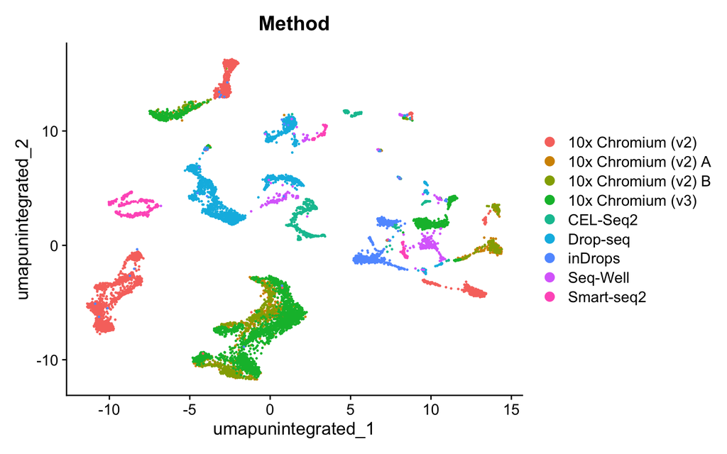

```r
Seurat::DimPlot(obj, reduction = "umap.unintegrated", group.by = "Method")
```

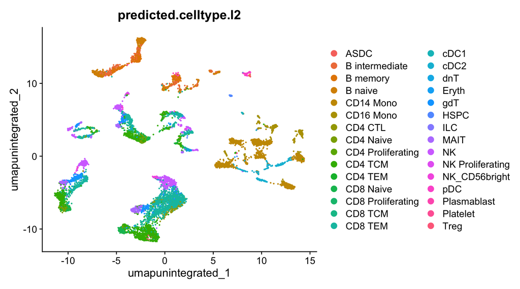

```r
Seurat::DimPlot(obj, reduction = "umap.unintegrated",
                group.by = "predicted.celltype.l2")
```

Hold these two panels side by side. In the first, the islands are almost uniformly single-coloured: Drop-seq occupies its own territory, Smart-seq2 and Seq-Well theirs, and only the three 10x runs partially overlap each other. In the second, the cell type labels *do* look coherent within each island — but the same label keeps reappearing in islands far apart. `CD14 Mono` shows up as several separate blobs on the right, `B naive` as three or four along the top.

That is the signature of an unintegrated multi-batch dataset: not one island per cell type, but one island per cell type **per batch**.

Before integrating, there is one prerequisite worth checking. Anchor-based methods assume the batches contain **the same cell types** — that is what makes “this cell in batch A matches that cell in batch B” a meaningful statement. The Azimuth labels let us check that directly, without any clustering:

```r
table(obj$predicted.celltype.l1, obj$Method)
```

```
##
##           10x Chromium (v2) 10x Chromium (v2) A 10x Chromium (v2) B
##   B                     494                  63                  66
##   CD4 T                 521                 133                 228
##   CD8 T                 317                 249                 228
##   DC                    104                  66                  42
##   Mono                  298                 200                 143
##   NK                    176                  77                  74
##   other                   3                   6                   4
##   other T               259                  50                  46
##
##           10x Chromium (v3) CEL-Seq2 Drop-seq inDrops Seq-Well Smart-seq2
##   B                     332       80      363       8       18         77
##   CD4 T                 605       97      559       6       38         81
##   CD8 T                1056      140      408       3       36        129
##   DC                     33        4       59      28       38         10
##   Mono                  424       43       58     490      190         72
##   NK                    224       71      178       5       11         79
##   other                   6        5        7       3       16          1
##   other T               186       64      178       2        3         63
```

No cell type is missing from any batch, which is the condition integration needs. But look at how unevenly they are represented: **inDrops is 90% monocytes, while Drop-seq is 3%**. Seq-Well is 54% monocytes; CEL-Seq2 and Smart-seq2 are more than half T cells.

That is a second kind of batch effect, and integration does not fix it. Aligning the batches makes a monocyte from one protocol land on a monocyte from another; it does not change the fact that one protocol captured 490 monocytes and another captured 58. Any comparison of cell type *proportions* across these batches is measuring capture chemistry, not biology.

> **If a batch genuinely lacks a cell type, integration will invent one.** The method’s job is to align populations across batches; handed a batch with no monocytes, it will still find the “best” match for the other batches’ monocytes and pull something onto them. Check this table before you integrate, not after you have a UMAP you like.

# 8 Integrating

`IntegrateLayers()` takes the per-batch layers and the unintegrated PCA, and returns a new reduction in which the batches are aligned.

```r
obj <- Seurat::IntegrateLayers(object = obj,
                               method = Seurat::CCAIntegration,
                               orig.reduction = "pca",
                               new.reduction = "integrated.cca",
                               verbose = FALSE)
obj
```

```
## An object of class Seurat
## 33789 features across 10434 samples within 4 assays
## Active assay: RNA (33694 features, 2000 variable features)
##  19 layers present: counts.Smart-seq2, counts.CEL-Seq2, counts.10x_Chromium_v2_A, counts.10x_Chromium_v2_B, counts.10x_Chromium_v3, counts.Drop-seq, counts.Seq-Well, counts.inDrops, counts.10x_Chromium_v2, data.Smart-seq2, data.CEL-Seq2, data.10x_Chromium_v2_A, data.10x_Chromium_v2_B, data.10x_Ch…
##  3 other assays present: prediction.score.celltype.l1, prediction.score.celltype.l2, prediction.score.celltype.l3
##  5 dimensional reductions calculated: integrated_dr, ref.umap, pca, umap.unintegrated, integrated.cca
```

This takes a couple of minutes on a laptop — the slowest step in the tutorial.

`CCAIntegration` is Seurat’s anchor-based method. Canonical correlation analysis finds directions of variation that are *shared* between two datasets rather than maximal within either one; cells that are mutual nearest neighbours in that shared space become **anchors**, and the anchors define the correction applied to everything else. The intuition worth keeping is that anchors are the method’s guess at “this cell in batch A and this cell in batch B are the same kind of cell”, and everything the method does downstream is only as good as that guess.

Four other methods are available through the same one-line interface, and switching between them is a change of one argument:

| `method =` | What it is |
| --- | --- |
| `CCAIntegration` | Anchor-based CCA. Strong correction; what we use here |
| `RPCAIntegration` | Anchor-based, reciprocal PCA. Faster and more conservative |
| `HarmonyIntegration` | Iterative clustering and correction in PCA space |
| `FastMNNIntegration` | Mutual nearest neighbours |
| `scVIIntegration` | Variational autoencoder; needs Python and `scvi-tools` |

Which to use is a real question with no universal answer, and it is Week 4’s material. The relevant fact for today is that trying a second one costs one line, so “we used CCA because it was in the tutorial” is not a defensible methods section when the alternative was that cheap.

```r
set.seed(10)
obj <- Seurat::RunUMAP(obj,
                       reduction = "integrated.cca",
                       dims = 1:30,
                       reduction.name = "umap.cca",
                       seed.use = 10)
```

Note that `RunUMAP()` is pointed at `integrated.cca` rather than `pca`. That is the entire behavioural difference between the integrated and unintegrated analyses: same object, same genes, same counts, different reduction.

# 9 Looking again

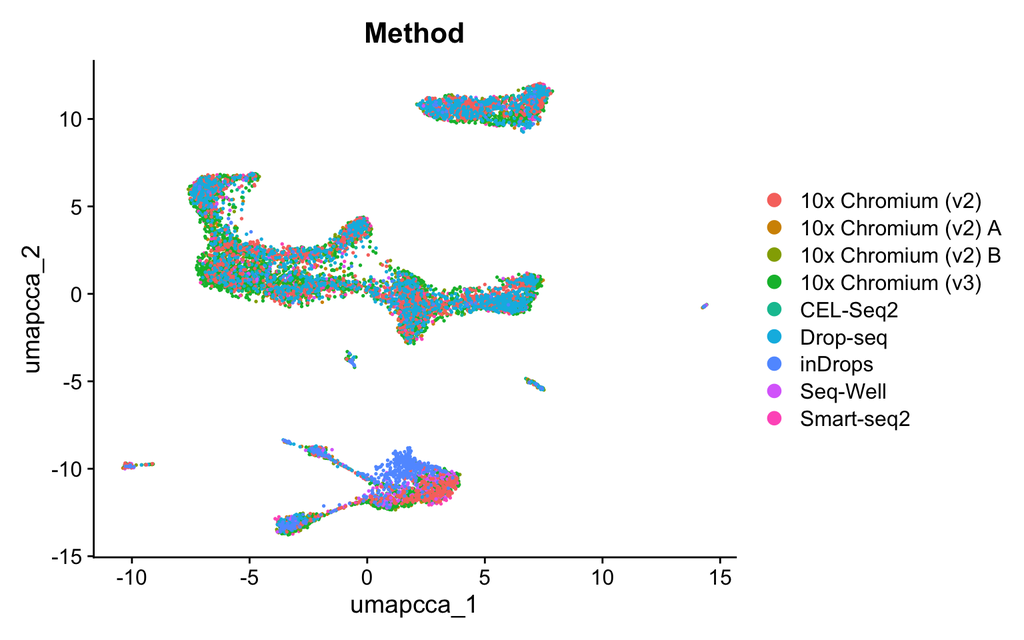

```r
Seurat::DimPlot(obj, reduction = "umap.cca", group.by = "Method")
```

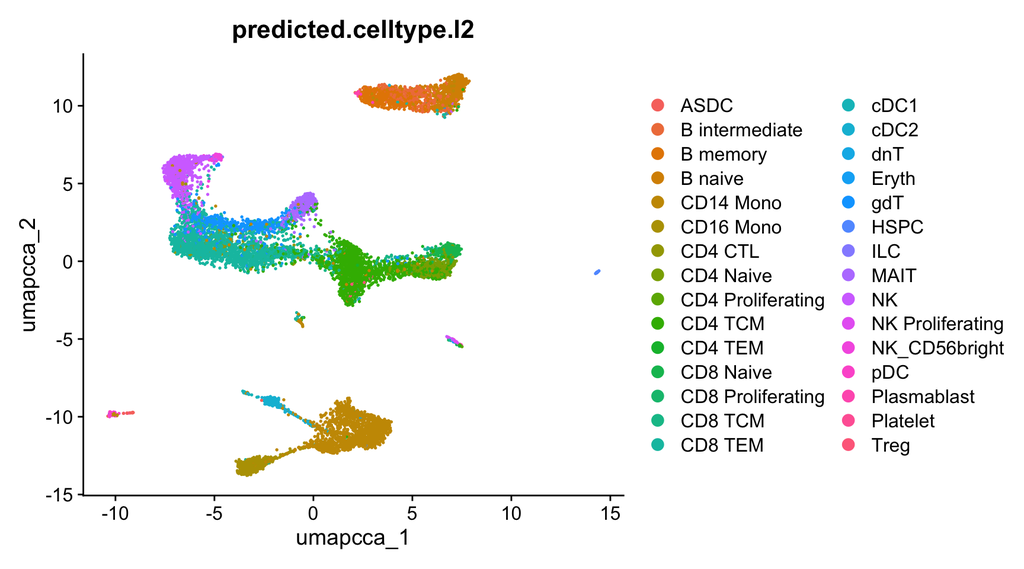

```r
Seurat::DimPlot(obj, reduction = "umap.cca",
                group.by = "predicted.celltype.l2")
```

Compare the first panel with its counterpart above. The single-coloured islands are gone; every island is now a speckled mixture of all nine technologies. One region at the bottom is still visibly blue, which we come back to in a moment.

The second panel is the one that matters, though, and it is why we ran Azimuth first. The Azimuth labels were assigned before integration and never updated, so the fact that the islands are now coherent in those labels — B cells along the top, monocytes along the bottom, T cells through the middle, each as **one** territory rather than several — is not something integration manufactured. It is the check that the mixing removed technology rather than biology.

## 9.1 What did not get fixed

Integration is not erasure, and it is worth looking for what survived rather than declaring victory. One region near the bottom of the integrated UMAP is still visibly blue — a patch where inDrops cells sit largely on their own instead of mixing. Reading it against the cell type panel, it sits inside the monocyte territory, which is exactly where the table above said to expect trouble: inDrops contributed 490 monocytes and very little else, so that population has far more inDrops cells to anchor to each other than to anything from the other batches.

A residual batch-specific patch is not automatically a failure. It can mean the correction was incomplete, or it can mean that one protocol genuinely captured a state the others missed — which, given that these nine batches differ in capture chemistry and lysis, is entirely plausible. The two explanations look identical in a UMAP. Telling them apart needs marker genes, not more integration.

# 10 Putting the layers back

Splitting the assay was for integration’s benefit. Almost everything downstream — differential expression above all — expects a single `counts` layer and a single `data` layer rather than nine of each.

```r
obj <- SeuratObject::JoinLayers(obj)
obj
```

```
## An object of class Seurat
## 33789 features across 10434 samples within 4 assays
## Active assay: RNA (33694 features, 2000 variable features)
##  3 layers present: data, counts, scale.data
##  3 other assays present: prediction.score.celltype.l1, prediction.score.celltype.l2, prediction.score.celltype.l3
##  6 dimensional reductions calculated: integrated_dr, ref.umap, pca, umap.unintegrated, integrated.cca, umap.cca
```

> **`JoinLayers()` lives in `SeuratObject`, not `Seurat`.** Writing `Seurat::JoinLayers(obj)` gives `'JoinLayers' is not an exported object from 'namespace:Seurat'`. Because both packages are attached by `library(Seurat)`, the unqualified `JoinLayers(obj)` works fine, which is why the mistake survives until someone adds namespaces. `Seurat::` is not a safe blanket prefix for everything in the Seurat ecosystem.

If you want to integrate again — a different method, a different `f =` — you can re-split at any time. The split is bookkeeping, not a transformation.

Finally, the prediction score matrices are still there, and worth seeing once so that the shape is not a surprise later:

```r
score_mat <- SeuratObject::LayerData(obj,
                                     assay = "prediction.score.celltype.l1")
dim(score_mat)
```

```
## [1]     8 10434
```

```r
rownames(score_mat)
```

```
## [1] "other T" "CD8 T"   "B"       "CD4 T"   "DC"      "NK"      "Mono"
## [8] "other"
```

```r
round(score_mat[1:5, 1:5], 3)
```

```
##         pbmc1_SM2_Cell_108 pbmc1_SM2_Cell_115 pbmc1_SM2_Cell_133
## other T              0.014                  0              0.011
## CD8 T                0.018                  0              0.000
## B                    0.000                  0              0.000
## CD4 T                0.000                  0              0.000
## DC                   0.000                  0              0.000
##         pbmc1_SM2_Cell_142 pbmc1_SM2_Cell_143
## other T                  0              0.000
## CD8 T                    1              0.238
## B                        0              0.000
## CD4 T                    0              0.000
## DC                       0              0.000
```

Eight rows for the eight level-1 cell types, one column per cell, and each column sums to one. `predicted.celltype.l1` is just the row name of the largest entry in each column; this matrix is where the rest of the distribution went.

# 11 The two ways to get this badly wrong

Everything above worked because `Method` is very nearly a purely technical variable, and because nobody cares which of two healthy donors a PBMC came from. Two mistakes break that, and both are common.

## 11.1 Confounding batch with your biology

Suppose you have twelve donors, six with Alzheimer’s disease and six controls, and — as happens constantly — the cases were processed in one batch and the controls in another. Integrate on batch and you will remove the disease effect, because in that design the disease effect *is* the batch effect. The UMAP will look beautiful. The differential expression will find nothing, or worse, find something.

No integration method can separate two variables that are perfectly confounded; this is a property of the design, not a deficiency of the software. What you can do:

- **Check first.** `table(obj$batch, obj$condition)` takes one second, and answers whether you have a problem before you spend a day integrating.
- **Balance at the bench.** Split conditions across batches when the samples are being processed. This is the only real fix, and it happens before any of us see the data.
- **When it is partial**, integrate on the technical variable and keep the biological one out of the split. With four batches each containing both cases and controls, integrating on batch is safe.
- **Consider not integrating.** Keeping the batch variable as a covariate in a differential expression model — or moving to pseudobulk, which sidesteps much of this — is often the more defensible route than correcting the embedding.

Run that check on this very dataset before assuming we got away with it:

```r
table(obj$Method, obj$Experiment)
```

```
##
##                       pbmc1 pbmc2
##   10x Chromium (v2)       0  2172
##   10x Chromium (v2) A   844     0
##   10x Chromium (v2) B   831     0
##   10x Chromium (v3)    2866     0
##   CEL-Seq2              235   269
##   Drop-seq              390  1420
##   inDrops               167   378
##   Seq-Well              337    13
##   Smart-seq2            239   273
```

`Experiment` is the donor. Four of the nine batches — 10x Chromium v2, v2 A, v2 B and v3 — contain cells from **one donor only**, and Seq-Well is 337 to 13. So `Method` and donor are *partially* confounded here, and some of what integration removed was donor difference rather than protocol difference.

That is survivable in this dataset for two reasons: five batches do span both donors, which is enough to anchor the alignment, and donor identity is not the thing anyone is trying to measure in a methods-comparison paper. Neither reason would hold if the two donors were a case and a control.

> **Do not skip this table on your own data.** It is one line, it runs before anything expensive, and it is the difference between removing a nuisance and removing your result. We ran it here and found partial confounding in a dataset specifically designed to be clean.

## 11.2 Testing genes on integrated values

The integrated output is a reduction — thirty-odd dimensions with no gene names. Some methods can also produce a corrected expression matrix, and it is tempting to run differential expression on it.

Do not. Integration deliberately removed variation it decided was batch, using anchors that assumed the batches contain the same cell types. Those assumptions are fine for arranging cells in a low-dimensional space and inappropriate as input to a statistical test, whose p-values assume the values are measurements rather than reconstructions.

**Cluster on the integrated reduction; test on the original counts.** Week 4 takes this up in detail.

# 12 What we glossed over

- **Why 30 dimensions?** Copied from the vignette, and consequential: the number of principal components fed to `IntegrateLayers()` and `RunUMAP()` sets how much structure either one can see. Choosing dimensionality — and clustering on top of the result — is the rest of **Week 3**.
- **Log-normalization versus `SCTransform`.** `IntegrateLayers()` accepts `normalization.method = "SCT"`, and the whole tutorial runs with SCTransform in place of `NormalizeData()` / `FindVariableFeatures()` / `ScaleData()`. The companion **Week 3** normalization tutorial covers what that substitution actually changes.
- **Which integration method, and how to tell.** We used CCA and never compared it with the four alternatives, and we never computed a real integration metric — kBET, LISI, silhouette by batch. We judged this one by eye, against labels fixed beforehand, which is honest but not quantitative. Note that any batch-mixing score alone rewards over-correction: a method that mashed everything into one blob would score perfectly, so mixing has to be read against a measure of preserved biology. **Week 4**.
- **Cell type labeling as a topic.** We ran one reference and read the scores. Choosing a reference, marker-based labeling, MapMyCells, and what to do when no reference fits your tissue are **Week 4**.
- **Differential expression after integration**, including pseudobulk and putting batch in the model rather than correcting it out — **Week 4**.
- **Ambient RNA and doublets.** We took `pbmcsca` as distributed and ran no Week 2 cleaning on it. On your own data, that cleaning comes first.
- **`mapping.score` went unused.** We computed it, quoted its quantiles, and never filtered on it. Cells that map poorly to the reference are exactly the cells whose labels should not be trusted in the evaluation above.

# 13 References

- Ding J, Adiconis X, Simmons SK, *et al.* *Systematic comparative analysis of single-nucleus and single-cell RNA-sequencing methods.* Nature Biotechnology 38:737–746, 2020. [doi:10.1038/s41587-020-0465-8](https://doi.org/10.1038/s41587-020-0465-8)
- Hao Y, Hao S, Andersen-Nissen E, *et al.* *Integrated analysis of multimodal single-cell data.* Cell 184:3573–3587, 2021. [doi:10.1016/j.cell.2021.04.048](https://doi.org/10.1016/j.cell.2021.04.048) — the source of the `pbmcref` reference and of the anchor-based framework.
- Seurat v5 vignette: [Integrative analysis in Seurat v5](https://satijalab.org/seurat/articles/seurat5_integration)
- Azimuth: [satijalab.github.io/azimuth](https://satijalab.github.io/azimuth/articles/run_azimuth_tutorial.html)